# Jacalz

Hello there. Welcome to my personal website.  
My name is Jacob and I am a Computer Science and Engineering student at Linköping University. Among other things, I am also a Linux user and amateur photographer.

# Current Projects

Below is a list of some of my current projects. These are in constant development.

## [Rymdport](https://github.com/Jacalz/rymdport)

Rymdport (formerly wormhole-gui) is a cross-platform application that lets you easily and safely share files, folders, and text between devices. The data is sent securely with end-to-end encryption using the same protocol as magic-wormhole. This means that Rymdport can talk not only to itself, but also to other wormhole clients.

The transfers are implemented using wormhole-william, a native [Go](https://go.dev/) implementation of magic-wormhole. As a result, Rymdport compiles into a native binary with no runtime dependencies while also outperforming the reference implementation of magic-wormhole.

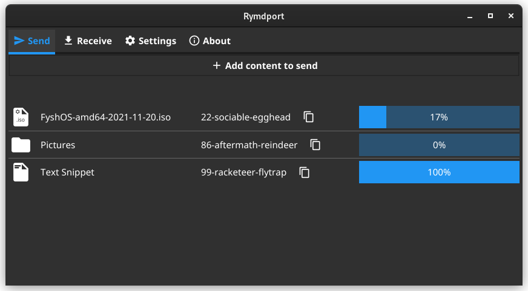

# Previous Projects

These projects are some that I have previously worked on but consider complete.

## [Super Chameleon](https://github.com/Jacalz/super-chameleon)

A 2D pixel art platformer inspired by Super Mario and made for a school project. In Super Chameleon, you play as a chameleon with abilities such as camouflaging and turning into a Jackson’s Chameleon, with horns. The game has been created using only open source software.

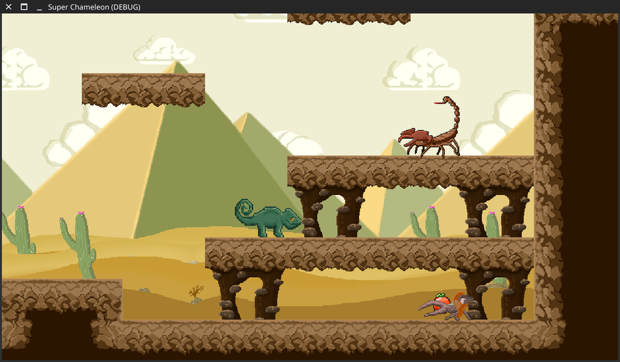